# Summary Tables with gtsummary

M08 Reflection and CEP Application

Han Mai

IBM 6500, Cal Poly Pomona

2026-11-11

# Module overview

## Learning and application

- Step 1: Dr. Jung’s descriptive, comparative, and regression tables.
- Step 2: Daniel Sjoberg’s reproducible reporting workflow and extensions.
- CEP application: 141 real Google Ads reported-call records, with measurement limits.

The CEP survey remains in design/pretesting. This application concerns recorded call patterns and duration. It cannot answer the planned survey questions about trust or consultation intention.

# Prompt 1

## Prompt 1: capabilities and value

## Descriptive and comparative tables

**Descriptive summaries**

tbl_summary() summarizes a data frame and can split results with by. It recognizes continuous, categorical, and dichotomous variables. Defaults include median (Q1, Q3), counts, and percentages.

Labels, type, statistic, digits, and missing-value arguments control the output. continuous2 allows several statistics on separate rows.

**Comparisons**

tbl_cross() creates contingency tables with margins and chosen percentage denominators. add_p() supplies comparison p-values. add_overall() and add_n() add context and available sample sizes.

Dr. Jung demonstrates Wilcoxon rank sum, Pearson chi-square, Welch t-tests, and proportion comparisons.

Source: Jung, Step 1 note sections 3-6 and lecture, 15:35-1:37:30.

## Testing and modeling

- add_difference() reports differences with confidence intervals and p-values. Adjustment for grade and stage demonstrates ANCOVA.
- tbl_regression() summarizes fitted logistic and OLS models. Exponentiating logistic coefficients produces odds ratios. OLS coefficients retain the modeled outcome scale.
- tbl_uvregression() fits separate one-predictor models and combines their summaries. It does not estimate one jointly adjusted multiple regression.
- add_global_p(), add_glance_table(), and add_vif() supply term-level tests, model information, or collinearity information in the examples.

Source: Jung, Step 1 sections 4.2 and 7-9. Lecture at 24:04-25:52 and 1:41:20-1:54:06.

Displaying mean/SD does not change add_p() to a t-test. I must inspect the test footnote and choose the analysis deliberately.

## Customization and publication

- Labels, statistics, precision, and missing-value display make the table informative.
- modify_header(), modify_spanning_header(), modify_footnote(), modify_caption(), and modify_fmt_fun() refine the output. bold_labels() and bold_p() emphasize selected content.
- add_q() adjusts p-values for multiple comparisons in the Bonferroni and false-discovery-rate examples.
- as_gt() enables gt formatting such as tab_header(). tbl_merge() combines columns and tbl_stack() combines rows.
- Journal themes coordinate reporting defaults. Dr. Jung contrasts JAMA and Quarterly Journal of Economics styles and resets themes between examples.

Source: Jung, Step 1 sections 4.4, 6.2, and 9-11.

## Value for school and marketing analytics

**School work.** I can keep the CEP analysis, tables, and explanation together in Quarto. When exclusions or coding change, tables recalculate. add_n() makes variable-specific missingness visible. Confidence intervals help me discuss uncertainty rather than only significance.

**Career.** Campaign and consumer-research reports need consistent labels and explicit denominators. These tools reduce copying console output into Excel and the risk of reporting an outdated coefficient. I can spend more time checking measurement and explaining what the evidence supports.

In my application, the location label’s meaning remains uncertain even after formatting. A publishable table should communicate that limitation.

# Prompt 2

## Prompt 2: extended presentation

The speaker’s name is Daniel Sjoberg. The prompt retains the instructor’s wording.

## 2.1: package roles

| Package | Role | Example or source |
| --- | --- | --- |
| gtsummary | Generates statistical summaries or organizes fitted-model results. | tbl_regression() creates a labeled regression table. |
| gt | Renders and formats general tables. | Sjoberg uses as_gt(), column widths, and alignment (43:06-46:09). |
| gtExtras | Adds helper functions and capabilities for gt tables. | The official package site describes wrappers around boilerplate and additional capabilities. |

Sjoberg explains that gtsummary uses gt in the background (1:54-2:11). **The assigned recording does not discuss gtExtras.** I used its official documentation to complete this comparison, rather than attributing it to the speaker.

Sources: Sjoberg (2021), Step 2. Supplemental source: [gtExtras official site](https://jthomasmock.github.io/gtExtras/).

## 2.2: new learning 1, synchronized narrative

**inline_text()** extracts formatted results from a gtsummary table for report prose (26:58-28:41).

Sjoberg retrieves the age odds ratio, confidence interval, and p-value. The pattern argument customizes the text.

Step 1 taught me to create tables. This adds a way to keep the written results synchronized. Below, I retrieve the hour coefficient directly from my regression table, reducing the risk that the sentence and table disagree after a revision.

## 2.2: new learning 2, stratified tables

**tbl_strata()** applies a table-building function within groups and then merges or stacks the results (32:33-33:28).

Sjoberg uses tumor grade as strata and generates a treatment summary within each grade. The new workflow is generating tables on subsets, beyond combining existing tables with tbl_merge() or tbl_stack().

For future CEP survey work, I could summarize decision-role differences within each city if sample sizes permit. The current call records lack respondent city and decision role, so this remains a future use case.

## 2.2: new learning 3, output engines

**Alternative print engines** separate statistical table construction from document formatting (43:02-46:09).

Sjoberg discusses gt, kable, flextable, kableExtra, huxtable, and tibble. He recommends flextable for Word and illustrates obtaining LaTeX through huxtable.

Step 1 demonstrates as_gt(). The broader engine selection is new to me. I would use HTML/gt for this revealjs assignment and evaluate Word-oriented output for client collaboration.

His comments about incomplete gt PDF/RTF support describe 2021 software, not a current compatibility test.

# Prompt 3

## Prompt 3: association in real CEP data

## Data provenance and suitability

**Source:** PhD Orthodontics Google Ads package, calls_UI_analysis.csv, extracted October 15, 2026. Selected package window: May 7-October 14, Pacific time.

**Unit:** one reported call record. N = 141 records, not verified unique people. Original fields are a record key, Pacific timestamp, seconds of duration, and caller-location label. No original field has NA values.

The current CEP methods say survey responses have not yet been collected. Shared Drive raw/cleaned folders were empty. I also inspected the real 107-row campaign-day export. It does not supply respondent variables or validated inquiry outcomes. Call metadata therefore supports a narrow exploratory application.

Source: [Group 6 CEP methods and data dictionary, modified November 2](https://sheilaaa0312.github.io/Group-6-PhD-Orthodontics/cep-group-6-report.html#survey-data), plus the actual source CSV.

## Variables and coding choices

| Variable | Definition | Relevance |
| --- | --- | --- |
| Day type | Monday-Friday versus Saturday/Sunday, from Pacific timestamp. | Natural calendar distinction for reviewing call coverage, without assuming opening hours. |
| Broad location label | California-identifying labels versus other/unspecified labels. | Consolidates rare geography cells and preserves uncertainty in national-only labels. |

**Other/unspecified does not mean outside California.** These derived metadata categories do not establish residence. I group small geography categories to reduce disclosure of rare city/state cells.

The question is whether recorded location-label composition differs by day type. Unknown repeat callers remain a limitation of independence.

## Data preparation code

```r
library(gtsummary)
library(dplyr)
library(gt)
input <- Sys.getenv("CEP_CALLS_CSV")
stopifnot(nzchar(input), file.exists(input))
raw <- read.csv(input)
stopifnot(nrow(raw) == 141, !anyNA(raw))
dt <- as.POSIXct(raw$date_time_pacific,
  format = "%Y-%m-%dT%H:%M", tz = "America/Los_Angeles")
stopifnot(!anyNA(dt), all(raw$duration_seconds >= 0))
```

Private input stays outside the repository. This presentation never prints record keys, exact timestamps, or source rows.

## Derived analysis variables

```r
d <- data.frame(
  duration = raw$duration_seconds,
  hour = as.POSIXlt(dt)$hour + as.POSIXlt(dt)$min / 60,
  weekpart = factor(ifelse(as.POSIXlt(dt)$wday %in% c(0, 6),
    "Weekend", "Weekday"), levels = c("Weekday", "Weekend")),
  location = factor(ifelse(grepl("California|, CA$",
    raw$caller_location_label), "California label",
    "Other or unspecified label"),
    levels = c("California label", "Other or unspecified label"))
)
```

No duration threshold defines a successful call. Zero-second records remain because their meaning is unvalidated.

## Association test and assumptions

```r
xt <- table(d$location, d$weekpart)
expected <- suppressWarnings(chisq.test(xt))$expected
expected
```

```
                              Weekday   Weekend
  California label           90.97163 10.028369
  Other or unspecified label 36.02837  3.971631
```

```r
fisher_result <- fisher.test(xt)
```

The smallest expected count is **3.97**. One of four cells (25%) is below five, so I use a **two-sided Fisher exact test** instead of the chi-square approximation.

Fisher addresses sparse cells. It does not establish independent callers or representative sampling. Its p-value is conditional on independent records.

## Publishable cross-tab code

```r
cross_tbl <- d |>
  tbl_cross(row = location, col = weekpart, percent = "column",
    label = list(location ~ "Broad caller-location label",
      weekpart ~ "Call day type")) |>
  add_p(test = "fisher.test",
    pvalue_fun = label_style_pvalue(digits = 2)) |>
  bold_labels()
cross_gt <- cross_tbl |> as_gt() |>
  tab_header(title = md("**Table 1. Recorded call timing and location labels**"),
    subtitle = "PhD Orthodontics Google Ads reported calls") |>
  tab_source_note("Column percentages. Two-sided Fisher exact test. N = 141 call records.") |>
  tab_options(table.font.size = px(28), data_row.padding = px(10))
```

## Table 1: timing and location labels

**Table 1. Recorded call timing and location labels**

PhD Orthodontics Google Ads reported calls

|  | **Call day type** Weekday | **Call day type** Weekend | **Total** | **p-value**<sup>1</sup> |  |  |
| --- | --- | --- | --- | --- | --- | --- |
| Broad caller-location label |  |  |  |  |  | >0.99 |
| California label | 91 (72%) | 10 (71%) | 101 (72%) |  |  |  |
| Other or unspecified label | 36 (28%) | 4 (29%) | 40 (28%) |  |  |  |
| Total | 127 (100%) | 14 (100%) | 141 (100%) |  |  |  |

<sup>1</sup> Fisher’s exact test  
Column percentages. Two-sided Fisher exact test. N = 141 call records.

Other/unspecified combines national-only and other-state labels. It cannot identify nonlocal patients.

## Statistical and practical interpretation

**Statistical conclusion**

California labels account for **91/127 (71.7%)** weekday records and **10/14 (71.4%)** weekend records.

Fisher exact **p = 1.00**. At alpha = .05, this analysis does not provide sufficient evidence of an association. It does not establish equivalence.

**CEP implication**

This extract gives no evidence supporting different geographic messaging by day type. Only 14 weekend records limit what can be learned.

Validate call outcomes and metadata before scheduling or targeting changes. Call volume also depends on ad delivery and exposure.

# Prompt 4

## Prompt 4: multiple regression

## Model specification

**Question:** How is recorded call duration associated with call time, day type, and broad location label?

**Outcome:** ln(duration in seconds + 1). Median duration is 61 seconds (IQR 16-125), range 0-1,063. Eight zero-second records remain. The log transformation reduces right-skew without creating a binary outcome.

**Predictors:** Pacific hour (continuous), weekend versus weekday, and other/unspecified versus California label. The model has three slopes and an intercept, with 141 complete observations.

This exploratory multiple OLS model concerns recorded duration. It cannot estimate consultation intention, lead quality, or the future survey model.

## Regression code

```r
fit <- lm(log1p(duration) ~ hour + weekpart + location, data = d)
tidy_hc3 <- function(x, conf.int = TRUE, conf.level = .95, ...) {
  ct <- lmtest::coeftest(x,
    vcov. = sandwich::vcovHC(x, type = "HC3"))
  out <- broom::tidy(ct)
  critical <- qt(1 - (1 - conf.level) / 2, df.residual(x))
  out$conf.low <- out$estimate - critical * out$std.error
  out$conf.high <- out$estimate + critical * out$std.error
  out
}
robust_results <- tidy_hc3(fit)
```

HC3 responds to observed unequal residual variance. Sjoberg demonstrates custom tidy_fun support, but this HC3 implementation is supplemental analysis, not a lecture claim. It cannot correct unidentified repeat callers.

## Regression table code

```r
reg_tbl <- tbl_regression(fit, tidy_fun = tidy_hc3,
  label = list(hour ~ "Pacific hour (per hour later)",
    weekpart ~ "Call day type",
    location ~ "Broad caller-location label"),
  estimate_fun = label_style_number(digits = 2),
  pvalue_fun = label_style_pvalue(digits = 2)) |>
  bold_labels() |> bold_p(t = .05)
reg_gt <- reg_tbl |> as_gt() |>
  tab_header(title = md("**Table 2. Associations with logged call duration**")) |>
  tab_source_note("OLS beta for ln(seconds + 1). HC3 SEs and t-based 95% CIs. N = 141.") |>
  tab_source_note("References: weekday and California label. Exploratory, noncausal model.") |>
  tab_options(table.font.size = px(28), data_row.padding = px(9))
```

## Table 2: multiple OLS results

**Table 2. Associations with logged call duration**

| **Characteristic** | **Beta** | **95% CI** | **p-value** |
| --- | --- | --- | --- |
| Pacific hour (per hour later) | 0.05 | -0.03, 0.14 | 0.20 |
| Call day type |  |  |  |
| Weekday | — | — |  |
| Weekend | -0.35 | -0.92, 0.23 | 0.24 |
| Broad caller-location label |  |  |  |
| California label | — | — |  |
| Other or unspecified label | -2.43 | -2.93, -1.93 | <0.001 |

Abbreviation: CI = Confidence Interval  
OLS beta for ln(seconds + 1). HC3 SEs and t-based 95% CIs. N = 141.  
References: weekday and California label. Exploratory, noncausal model.

R-squared = 0.54 and adjusted R-squared = 0.53. These describe in-sample fit, not external predictive performance.

## Coefficient interpretation

- **Other/unspecified label:** beta = -2.43, HC3 95% CI [-2.93, -1.93], p < .001, relative to California labels. Holding hour and day type constant, the modeled logged duration is lower. exp(beta) is approximately 0.088, a ratio on the duration-plus-one scale, not an odds ratio.
- **Hour:** beta = 0.055, 95% CI [-0.029, 0.139], p = .198. Each hour later corresponds to that expected change in the logged outcome, holding other predictors constant.
- **Weekend:** beta = -0.346, 95% CI [-0.922, 0.231], p = .238 relative to weekday, holding hour and location label constant.

Only the location-label contrast is significant among the slopes at .05. Time effects remain uncertain. No coefficient establishes causality.

## Synchronized narrative with inline_text()

```r
hour_text <- inline_text(reg_tbl, variable = hour,
  pattern = "beta = {estimate}, 95% CI {conf.low} to {conf.high}, p = {p.value}")
```

This retrieves the same formatted result shown in Table 2. If I update the model, the narrative updates too. This directly applies a new Step 2 workflow and reduces manual transcription.

## Diagnostic code

```r
bp <- lmtest::bptest(fit)
reset <- lmtest::resettest(fit)
normality <- shapiro.test(residuals(fit))
max_cook <- max(cooks.distance(fit))
mm <- model.matrix(fit)[, -1, drop = FALSE]
vifs <- sapply(seq_len(ncol(mm)), function(j) {
  1 / (1 - summary(lm(mm[, j] ~ mm[, -j]))$r.squared)
})
cluster_ct <- lmtest::coeftest(fit,
  vcov. = sandwich::vcovCL(fit, cluster = as.Date(dt), type = "HC1"),
  df = length(unique(as.Date(dt))) - 1)
```

Same-day clustered sensitivity checks shared-date dependence without publishing dates. It cannot correct repeat callers across days.

## Diagnostics and limitations

[output not shown]

There are 141 records on 78 dates. This historical platform extract is not a probability sample. Normality, independence, outcome validity, and external generalization remain limitations.

## Residual inspection

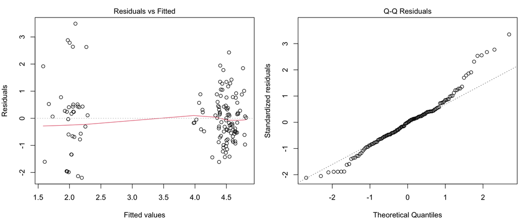

Unlabeled residual diagnostics contain no caller identifiers or timestamps. HC3 addresses unequal variance, but does not repair measurement errors or establish independence.

## Sensitivity and CEP meaning

Sensitivity: standard errors clustered by call date

| Predictor | Beta | Cluster SE | p-value |
| --- | --- | --- | --- |
| Pacific hour | 0.055 | 0.036 | 0.14 |
| Weekend | −0.346 | 0.187 | 0.068 |
| Other/unspecified label | −2.429 | 0.249 | <0.001 |

The location contrast could reflect routing, metadata specificity, or short/zero calls. It cannot show that nonlocal prospects are less valuable. Validate labels and inquiry outcomes before changing audience exclusions, budget, or call coverage.

# Key takeaways

## What I will carry into the CEP

- Match the statistic and table to the measurement level and observational unit.
- Check missingness, sparse cells, and model behavior before formatting.
- Keep code, tables, and prose synchronized with tbl_cross(), tbl_regression(), as_gt(), and inline_text().
- Preserve the distinction between calls, inquiries, bookings, and patients.

For the future survey, I will assess dimensionality and reliability before forming composites. The current CEP plan specifically keeps information-quality facets separate.

# References

## Course sources

- Jung, Jae (2026). [Summary table with gtsummary](https://jaejungca.github.io/gtsummary/M08-Customizable%20Tables-gtsummary.html), October 30. Entire note, sections 1-12.
- Jung, Jae. [Publishable Modeling Results Summary Table with gtsummary](https://streaming.cpp.edu/embed/secure/iframe/entryId/1_94dlhnul/uiConfId/52359092/st/0), assigned Step 1 lecture. Displayed duration 2:04:41.
- Sjoberg, Daniel (2021). [Presentation-ready Summary Tables with gtsummary](https://www.youtube.com/watch?v=tANo9E1SYJE), Weill Cornell Computing Club, April 27. Full 52:17 presentation and Q&A. [Speaker slides](https://www.danieldsjoberg.com/gtsummary-weill-cornell-presentation/).
- [gtsummary summary-table documentation](https://www.danieldsjoberg.com/gtsummary/articles/tbl_summary.html) and [regression documentation](https://www.danieldsjoberg.com/gtsummary/articles/tbl_regression.html), linked by the Step 1 note.

## Supplemental and CEP sources

- Mock, Thomas. [gtExtras official documentation](https://jthomasmock.github.io/gtExtras/). Used only for Prompt 2.1 because the assigned recording does not discuss this package.
- Group 6 (2026). [PhD Orthodontics CEP methods and dictionary](https://sheilaaa0312.github.io/Group-6-PhD-Orthodontics/cep-group-6-report.html#sec-ch3-methods), modified November 2. Survey status and measurement decisions.
- PhD Orthodontics Google Ads package, October 15, 2026. Restricted calls_UI_analysis.csv. Access to the source is required to reproduce calculations. Restricted row-level records remain outside the public repository.

sandwich and lmtest supply the supplemental HC3 and clustered covariance checks.<sup>1</sup>

[^1]: Robust standard errors cannot identify or correct unknown repeated callers across dates.

# Appendix

## Reproducibility and privacy

- Open **M08.Rproj** first.
- Install gtsummary, dplyr, gt, broom, lmtest, sandwich, and quarto from CRAN as needed.
- Set CEP_CALLS_CSV to an authorized local copy of calls_UI_analysis.csv outside the repository.
- Render Han-Mai-M08-Reflection-Essay-gtsummary.qmd. HTML embeds resources.
- Public output includes code and aggregate statistical results. Exact call timestamps, record keys, identifiers, and row-level data stay private.

**Data caveat:** uncertainty calculations require assumptions about independent records. Unique caller identity and verified inquiry outcomes are unavailable. These results support exploration and measurement QA.

## GitHub links

**GitHub Repository**

[Open GitHub repository](https://github.com/hanamai111/ibm6500-m08-gtsummary-reflection)

**GitHub Pages**

[Open published presentation](https://hanamai111.github.io/ibm6500-m08-gtsummary-reflection/)

**Public source materials**

[Step 1 lecture note](https://jaejungca.github.io/gtsummary/M08-Customizable%20Tables-gtsummary.html) and [Step 2 presentation](https://www.youtube.com/watch?v=tANo9E1SYJE)